# Atividade prática n. 2

Grupo 9

04 de outubro de 2022

**Relatório do grupo 9**

Tema: *relatório completo sobre investimento em empresas estatais*

## Questão 0:

Iniciando os modulos, os dados para as analises e as funções necessarias

```r
#install.packages("stargazer")
library(stargazer)
```

## Questão 1:

Baixe o relatório e declare no R que a coluna Data contém informações temporais.

```r
data <- read.csv("ArquivoExercicio2.csv",sep=";",header=TRUE)

data$Data <- as.Date(data$Data)
```

## Questão 2:

Crie no R gráficos com os retornos dos 3 ativos ao longo do tempo. Analise os resultados dando destaque ao período da pandemia de COVID-19.

Graficos da BBSA3

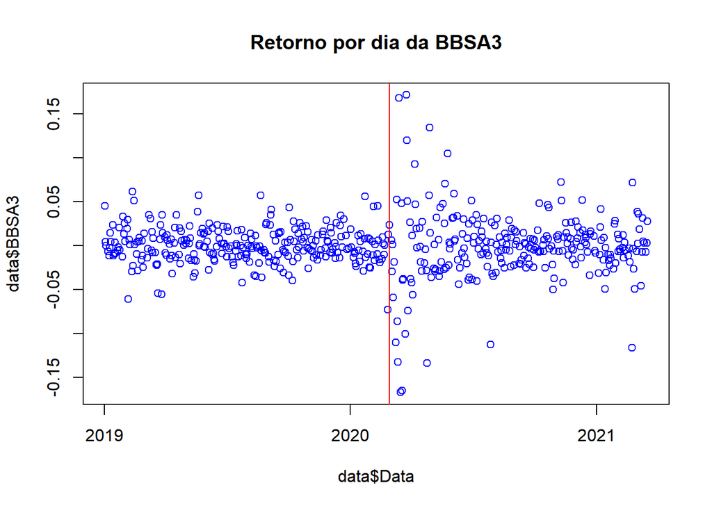

```r
plot(data$Data,data$BBSA3,col="Blue",
     main = "Retorno por dia da BBSA3")
abline(v=18320,col="Red")
```

Graficos da PETR4

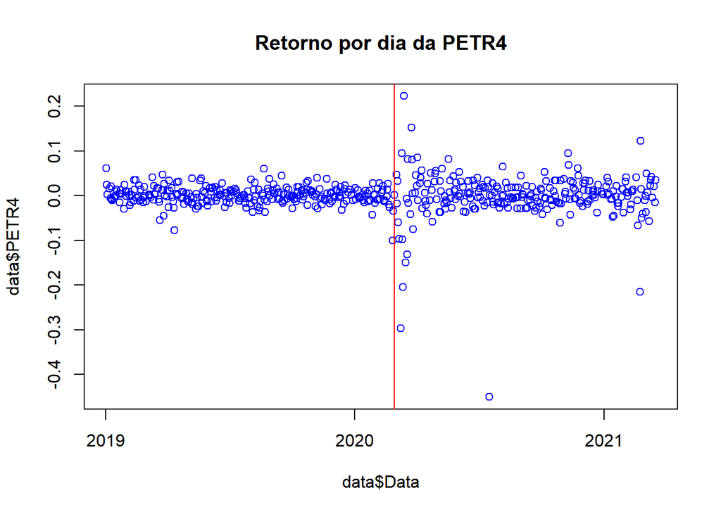

```r
plot(data$Data,data$PETR4,col="Blue",
     main = "Retorno por dia da PETR4")
abline(v=18320,col="Red")
```

Graficos da CMIG4

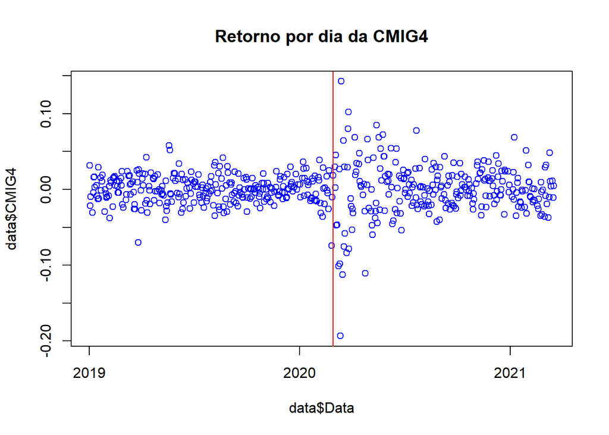

```r
plot(data$Data,data$CMIG4,col="Blue",
     main = "Retorno por dia da CMIG4")
abline(v=18320,col="Red")
```

- Data inicial da pandemia indicada pela linha vermelha (2020-03-01) Podemos observar que as três empresas apresentavam retornos relativamente constantes e não muito dispersos. Particularmente, a Petrobrás é a que apresenta um retorno mais centrado no 0, enquanto a Cemig e o Banco do Brasil apresentam retornos um pouco mais dispersos, mas também perto do 0. Agora, na época da pandemia do Covid-19, podemos observar uma grande dispersão dos retornos, formando quase uma linha vertical no gráfico, o que indica que os retornos foram mais inconstantes nesse período inicial da pandemia. Agora, como as duas empresas são muito consistentes no mercado, pouco tempo depois da pandemia, elas já voltaram a ter retornos mais pre-pandemia.